# Part 4: Functions

Authors

Gerko Vink

Javier Garcia-Bernardo

Hanne Oberman

Published

November 20, 2025

Functions in R are like magic tools that make your coding life easier. Instead of writing long, confusing chunks of code, you can create functions to do specific tasks. This makes your code neat, easy to understand, and less prone to mistakes. Imagine you have a set of instructions you use often; with a function, you can package those instructions and reuse them whenever you need. R already has lots of built-in functions, and you can create your own too.

Just remember to give your functions clear names and explain what they do–it’s like leaving a note for your future self (or others) to understand your code better.

## Exercise 1: Functions

1. **Create a function that calculates the sample standard deviation of a vector of numbers. Validate it by comparing the output to the function `sd()`. Write documentation for such function.**

$$\sigma = \sqrt{\frac{1}{N-1}\sum_{i=0}^N{(x_i - \bar{x})^2}}$$

```r
#' Calculate the standard deviation of a
#' \sigma = \sqrt{\frac{1}{N-1}\sum_{i=0}^N{(x_i - \bar{x})^2}}$$
#'
#' @param values A numeric vector
#' @returns STD of the vector
#' @examples
#' std_own(c(3,5,4))
std_own <- function(values) {
  s <- sqrt(1/(length(values)-1)*sum((values - mean(values))^2))
  return(s)
}

std_own(c(1,2,3,3))
```

```
[1] 0.9574271
```

```r
sd(c(1,2,3,3))
```

```
[1] 0.9574271
```

In this practical I will be explicitly specifying the package of each function (e.g. readr::read_delim). Specifying the package is not required and can be cumbersome for the most commonly used functions. I do it to show the source of the functions you are using.

First, open the R project you created last week (or create a new one).

Then, load the required library (tidyverse). Look at the output, which packages does it load?

```r
library(tidyverse)
```

In the following exercises we will use the same dataset as last time, boys. You need to download `dataset_boys.csv` from [here](https://javier.science/R/#day-2-1) and add it to a folder “data” in the same folder as your markdown file.

Then, read the file dataset_boys.csv using the code in the next cell. The dataset contains the growth of Dutch boys in the 20th century ([amices.org/mice](https://amices.org/mice/reference/boys.html)).

```r
#Reading the file
boys <- readr::read_delim("data/dataset_boys.csv",delim=",")
is_tibble(boys)
```

```
[1] TRUE
```

## Exercise 2-6: Tidyverse operations

2.**Using `filter()`, create a new tibble with the boys younger than 15 that do not live in the “north” region, and calculate their average age.**

```r
age_subset <- dplyr::filter(boys,
                            (age < 15),
                            (reg != "north")
                            )
mean(age_subset$age, na.rm=TRUE)
```

```
[1] 6.044461
```

3. **Using `select()`, select the variables bmi and wgt of the tibble you just created**

```r
age_subset_two_cols <- dplyr::select(age_subset, bmi, wgt)
```

4. **Using `mutate()`, create two new variables, one call `hgt_square` (hgt^2), and another called `bmi_2` (10000 $\times$ wgt/hgt_square)**.

```r
# The arguments are evaluated sequentially in tidyverse, by the time we get to bmi_2 the computer has already created hgt_square
boys <- dplyr::mutate(boys,
                      hgt_square = hgt^2,
                      bmi_2 = 10000 * wgt / hgt_square)
```

5. **Using `group_by()` and `summarize()`, group by `region`, and calculate the average `bmi`, `wgt` and `hgt`. You could use a pipe to make it more compact.**

```r
# Without a pipe
gr_boys <- dplyr::group_by(boys, reg)
boys_mean <- dplyr::summarize(gr_boys,
                              mean_bmi = mean(bmi, na.rm=TRUE),
                              mean_wgt = mean(wgt, na.rm=TRUE),
                              mean_hgt = mean(hgt, na.rm=TRUE))

# With a pipe
boys_mean <-boys |>
            dplyr::group_by(reg) |>
            dplyr::summarize(mean_bmi = mean(bmi, na.rm=TRUE),
                             mean_wgt = mean(wgt, na.rm=TRUE),
                             mean_hgt = mean(hgt, na.rm=TRUE))
```

6. **Using `arrange()`, sort the dataset by `bmi`, what can you say about the boys with low BMI?**

```r
#They are small babies
dplyr::arrange(boys, bmi)
```

```
# A tibble: 748 × 11
      age   hgt   wgt   bmi    hc gen   phb      tv reg   hgt_square bmi_2
    <dbl> <dbl> <dbl> <dbl> <dbl> <chr> <chr> <dbl> <chr>      <dbl> <dbl>
 1  0.038  53.5  3.37  11.8  35   <NA>  <NA>     NA south      2862.  11.8
 2  0.164  55    3.73  12.3  37.8 <NA>  <NA>     NA west       3025   12.3
 3  0.057  50    3.14  12.6  35.2 <NA>  <NA>     NA south      2500   12.6
 4  0.071  55.1  3.88  12.8  36.8 <NA>  <NA>     NA west       3036.  12.8
 5  0.191  56.9  4.14  12.8  35.7 <NA>  <NA>     NA south      3238.  12.8
 6  0.09   55.7  4.07  13.1  36.6 <NA>  <NA>     NA east       3102.  13.1
 7  0.202  60    4.79  13.3  38.2 <NA>  <NA>     NA west       3600   13.3
 8  3.96  105.  14.6   13.3  47.6 <NA>  <NA>     NA south     10962.  13.3
 9  0.197  58    4.55  13.5  38.3 <NA>  <NA>     NA south      3364   13.5
10 11.1   135.  25     13.7  48.2 G1    P2        2 west      18252.  13.7
# ℹ 738 more rows
```

## Exercises 7–10: Data transformations

7. **Inspect the dataset `tidyr::table2`. Could you easily create the cases of `TB` per capita?**

*Hint: You only need to print `tidyr::table2`.*

```r
tidyr::table2
```

```
# A tibble: 12 × 4
   country      year type            count
   <chr>       <dbl> <chr>           <dbl>
 1 Afghanistan  1999 cases             745
 2 Afghanistan  1999 population   19987071
 3 Afghanistan  2000 cases            2666
 4 Afghanistan  2000 population   20595360
 5 Brazil       1999 cases           37737
 6 Brazil       1999 population  172006362
 7 Brazil       2000 cases           80488
 8 Brazil       2000 population  174504898
 9 China        1999 cases          212258
10 China        1999 population 1272915272
11 China        2000 cases          213766
12 China        2000 population 1280428583
```

8. **Transform the data to make it tidy** **Then, calculate the cases of TB per 1 million people. Which country had the highest cases per capita?**

*Hint: Do you have values in the column names and you need to make the data longer? Or do you have more than one variable in one column and you need to make the data wider?*

```r
# Without a pipe
table2_tidy <- tidyr::pivot_wider(
  table2,
  id_cols = c("country", "year"),
  names_from = "type",
  values_from = "count"
)

table2_tidy <- dplyr::mutate(
  table2_tidy,
  cases_per_capita = 1E6 * cases / population
  )
table2_tidy <- dplyr::arrange(table2_tidy, desc(cases_per_capita))
```

```r
#Or with a pipe
table2_tidy <- table2 |>
  tidyr::pivot_wider(id_cols = c("country","year"),
                     names_from = "type",
                     values_from = "count") |>
  dplyr::mutate(cases_per_capita = 1E6*cases/population) |>
  dplyr::arrange(desc(cases_per_capita))
```

9. **Print the datasets tidyr::table4a (cases of TB) and tidyr::table4b (population). Tidy them and save the output tables with names table4a_tidy and table4ab_tidy** *Do you have values in the column names and you need to make the data longer? Or do you have more than one variable in one column and you need to make the data wider?*

```r
table4a_tidy <- tidyr::pivot_longer(
  table4a,
  cols = c("1999", "2000"),
  names_to = "year",
  values_to = "TB"
  )
head(table4a_tidy)
```

```
# A tibble: 6 × 3
  country     year      TB
  <chr>       <chr>  <dbl>
1 Afghanistan 1999     745
2 Afghanistan 2000    2666
3 Brazil      1999   37737
4 Brazil      2000   80488
5 China       1999  212258
6 China       2000  213766
```

```r
table4b_tidy <-  tidyr::pivot_longer(
  table4b,
  cols = c("1999", "2000"),
  names_to = "year",
  values_to = "Pop"
  )
head(table4b_tidy)
```

```
# A tibble: 6 × 3
  country     year         Pop
  <chr>       <chr>      <dbl>
1 Afghanistan 1999    19987071
2 Afghanistan 2000    20595360
3 Brazil      1999   172006362
4 Brazil      2000   174504898
5 China       1999  1272915272
6 China       2000  1280428583
```

10. **Join table4a_tidy and table4b_tidy, and calculate the cases of TB per 1 million people? Which country had the highest cases per capita?** Could you have done this with table4a and table4b?

```r
#With a pipe
table4 <- dplyr::inner_join(table4a_tidy, table4b_tidy, by = c("country", "year")) |>
          dplyr::mutate(cases_per_capita = 1E6*TB/Pop) |>
          dplyr::arrange(desc(cases_per_capita))
```

## Exercises 11–13: Linear regression

11. **Using the boys dataset, fit a model where the weight depends on the age and the region.**

```r
fit <- stats::lm(wgt ~ age + reg, data=boys)
fit
```

```
Call:
stats::lm(formula = wgt ~ age + reg, data = boys)

Coefficients:
(Intercept)          age      regeast     regnorth     regsouth      regwest
     4.4607       3.5700      -0.5003       2.9150      -0.6380      -0.1513
```

12. **Print the regression table using the function summary. Does the region have a significant effect?**

```r
summary(fit)
```

```
Call:
stats::lm(formula = wgt ~ age + reg, data = boys)

Residuals:
    Min      1Q  Median      3Q     Max
-21.985  -3.917   0.343   2.558  47.947

Coefficients:
            Estimate Std. Error t value Pr(>|t|)
(Intercept)  4.46070    1.00956   4.418 1.14e-05 ***
age          3.57005    0.04347  82.118  < 2e-16 ***
regeast     -0.50031    1.13805  -0.440   0.6603
regnorth     2.91498    1.31025   2.225   0.0264 *
regsouth    -0.63801    1.10914  -0.575   0.5653
regwest     -0.15125    1.08042  -0.140   0.8887
---
Signif. codes:  0 '***' 0.001 '**' 0.01 '*' 0.05 '.' 0.1 ' ' 1

Residual standard error: 8.06 on 735 degrees of freedom
  (7 observations deleted due to missingness)
Multiple R-squared:  0.9047,    Adjusted R-squared:  0.9041
F-statistic:  1396 on 5 and 735 DF,  p-value: < 2.2e-16
```

13. **Check the assumptions of linear regression using plot(). Are the assumptions met? What are the biggest outliers? (find them in the data)** Homoscedasticity and independence of residuals (which = 1). Normality of residuals (which = 2) and presence of outliers (which = 6).

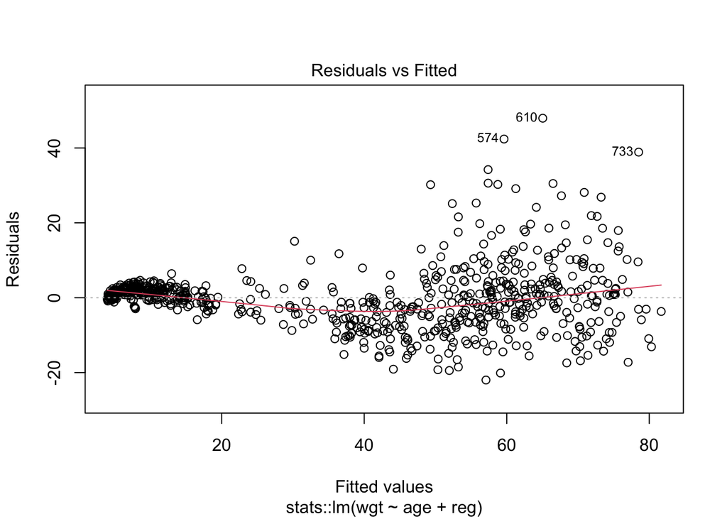

```r
# There shouldn't be strange patterns
plot(fit, which = 1)
```

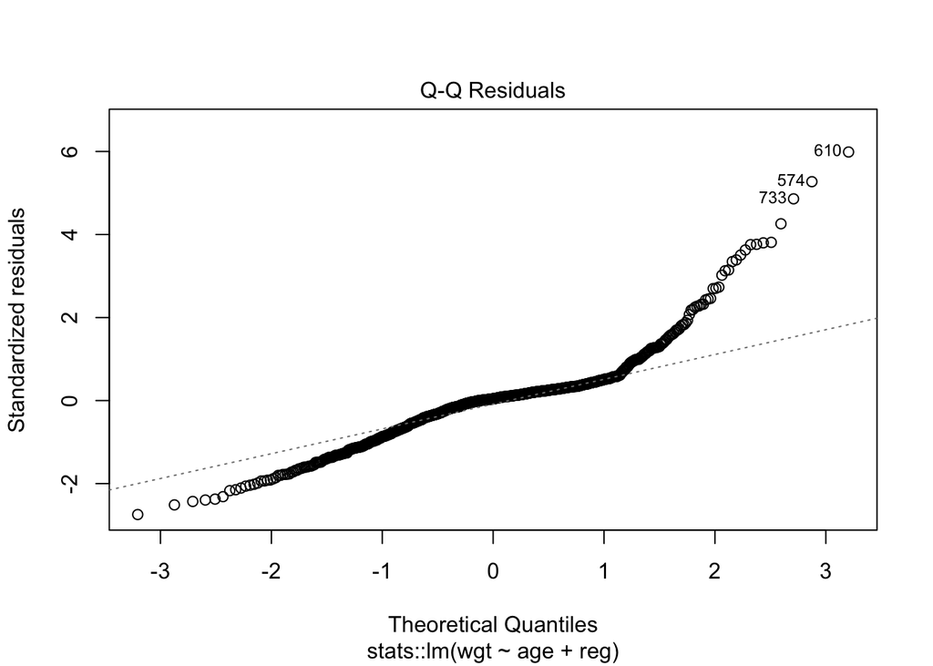

```r
# The points should lie on the line
plot(fit, which = 2)
```

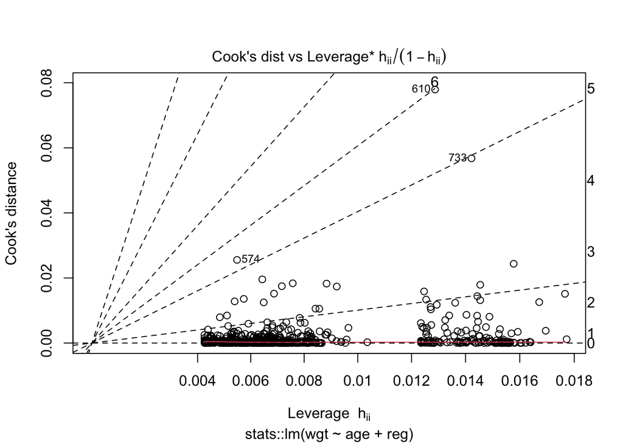

```r
# Cook's distance measures the effect of deleting a given observation.
# Leverage is a measure of how far away the independent variable values of an observation are from those of the other observations.
plot(fit, which = 6)
```

```r
# Checking outliers
slice(boys, c(733,610,574))
```

```
# A tibble: 3 × 11
    age   hgt   wgt   bmi    hc gen   phb      tv reg   hgt_square bmi_2
  <dbl> <dbl> <dbl> <dbl> <dbl> <chr> <chr> <dbl> <chr>      <dbl> <dbl>
1  19.9  192.  117.  31.7  57.6 G5    P6       18 north     36979.  31.7
2  16.2  194.  113   29.9  58.4 G3    P5        6 north     37752.  29.9
3  15.5  182.  102   30.6  57.7 <NA>  <NA>     NA west      33306.  30.6
```

## Exercise 14. Saving data

14. **Save the data `boys` as an RDS file, and as an Excel file**. Remember to save your data to the data folder!

```r
readr::write_rds(boys, "data/boys.rds")
writexl::write_xlsx(boys, "data/boys.xlsx")
```

## Exercise 15–16. Some visualizations

First, install the library datasauRus and load it

```r
#install.packages("datasauRus")
library(datasauRus)
```

15. Group datasauRus::datasaurus_dozen by the variable `dataset` and calculate the mean and standard deviation of both x and y, and the correlation (function `cor()`) between x and y.

```r
datasauRus::datasaurus_dozen |>
      dplyr::group_by(dataset) |>
      dplyr::summarize(mean_x = mean(x),
                mean_y = mean(y),
                sd_x = sd(x),
                sd_y = sd(y),
                cor(x,y))
```

```
# A tibble: 13 × 6
   dataset    mean_x mean_y  sd_x  sd_y `cor(x, y)`
   <chr>       <dbl>  <dbl> <dbl> <dbl>       <dbl>
 1 away         54.3   47.8  16.8  26.9     -0.0641
 2 bullseye     54.3   47.8  16.8  26.9     -0.0686
 3 circle       54.3   47.8  16.8  26.9     -0.0683
 4 dino         54.3   47.8  16.8  26.9     -0.0645
 5 dots         54.3   47.8  16.8  26.9     -0.0603
 6 h_lines      54.3   47.8  16.8  26.9     -0.0617
 7 high_lines   54.3   47.8  16.8  26.9     -0.0685
 8 slant_down   54.3   47.8  16.8  26.9     -0.0690
 9 slant_up     54.3   47.8  16.8  26.9     -0.0686
10 star         54.3   47.8  16.8  26.9     -0.0630
11 v_lines      54.3   47.8  16.8  26.9     -0.0694
12 wide_lines   54.3   47.8  16.8  26.9     -0.0666
13 x_shape      54.3   47.8  16.8  26.9     -0.0656
```

16. **Use the following code to visualize the data.** *The descriptive statistics were identical, but do the datasets look similar?*

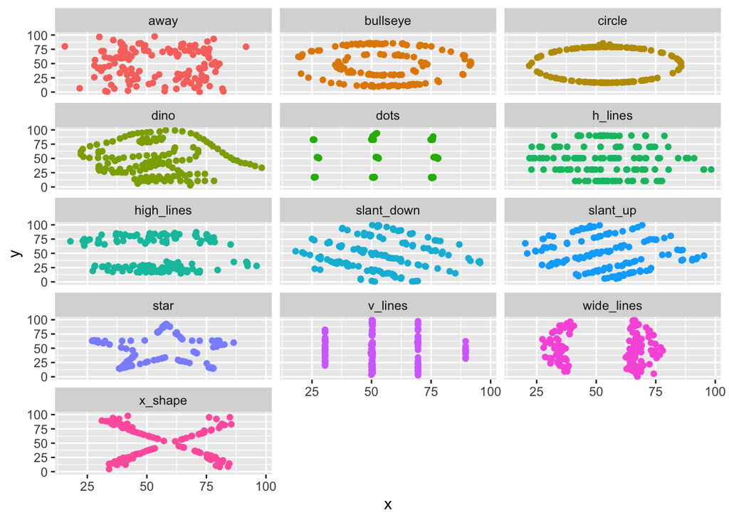

```r
ggplot(datasaurus_dozen, aes(x=x, y=y, colour=dataset))+
    geom_point()+
    theme(legend.position = "none")+
    facet_wrap(~dataset, ncol=3)
```

End of Practical.

#### References

Matejka, J., & Fitzmaurice, G. (2017). Same Stats, Different Graphs: Generating Datasets with Varied Appearance and Identical Statistics through Simulated Annealing. CHI 2017 Conference proceedings: ACM SIGCHI Conference on Human Factors in Computing Systems.

—  
Copyright Hanne Oberman, 2025 - [CC BY-NC-SA 4.0](https://creativecommons.org/licenses/by-nc-sa/4.0/)  
Materials developed by [Amices](https://amices.org) team - Methodology & Statistics - Utrecht University